WorCAP 2026 / Saved results

# From the hackathon to monthly forecasts.

I started with a competition submission and kept working toward forecasts made before the month begins. Explore the saved maps and historical results from both versions below.

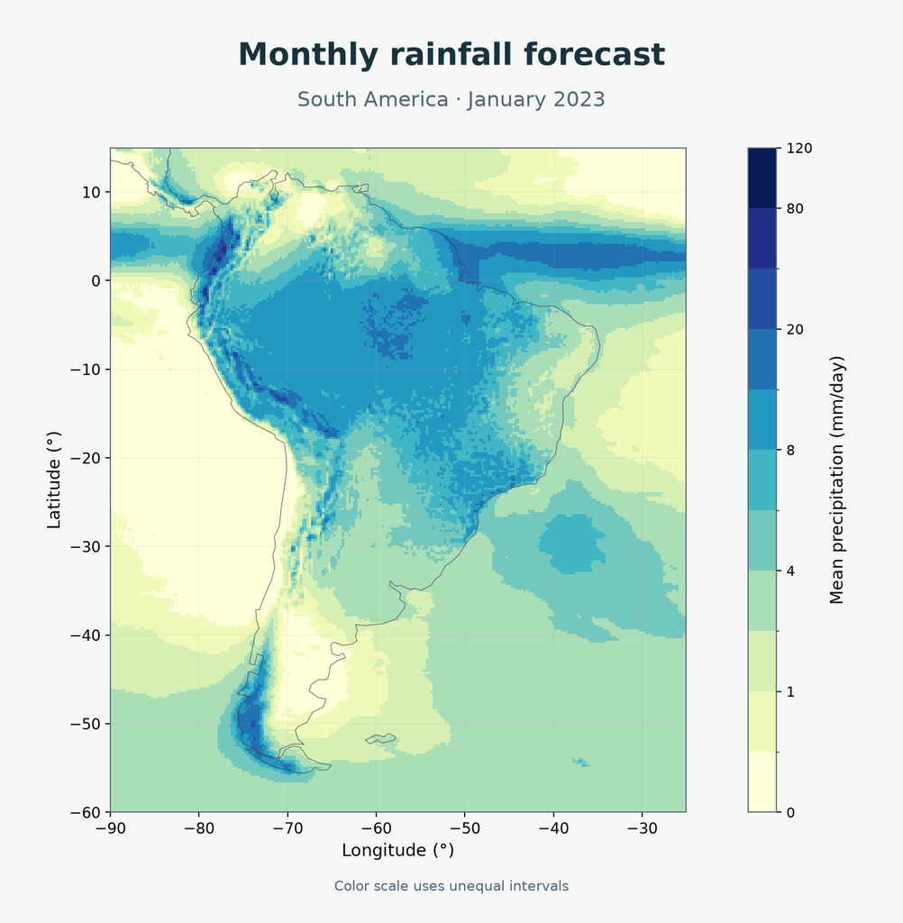

### About this map

The first month from the verified submission CSV, produced by a model trained on 1993–2022. It was chosen chronologically, not by performance, and shows predicted rainfall rather than observations.

Download PNG

## Historical validation

2007–2020 · Seven two-year blocks · All metrics in mm/day

Metric

**View exact values**

**How to read these results**

Two LightGBM models and local ridge regression are combined with fixed weights of 37.5%, 37.5% and 25%. Each historical block uses its own earlier training window. These metrics do not score the map above or represent the competition's final score.

SAVED MAPS

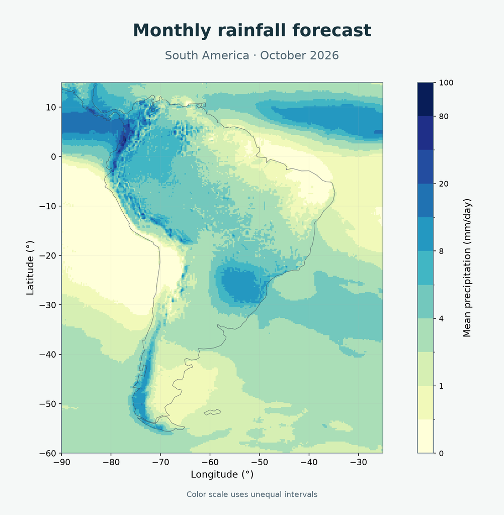

### About this map

Issued on 30 September 2026 at 18:18 UTC, before the target month began. Evaluation against final ERA5 can begin from 1 February 2027.

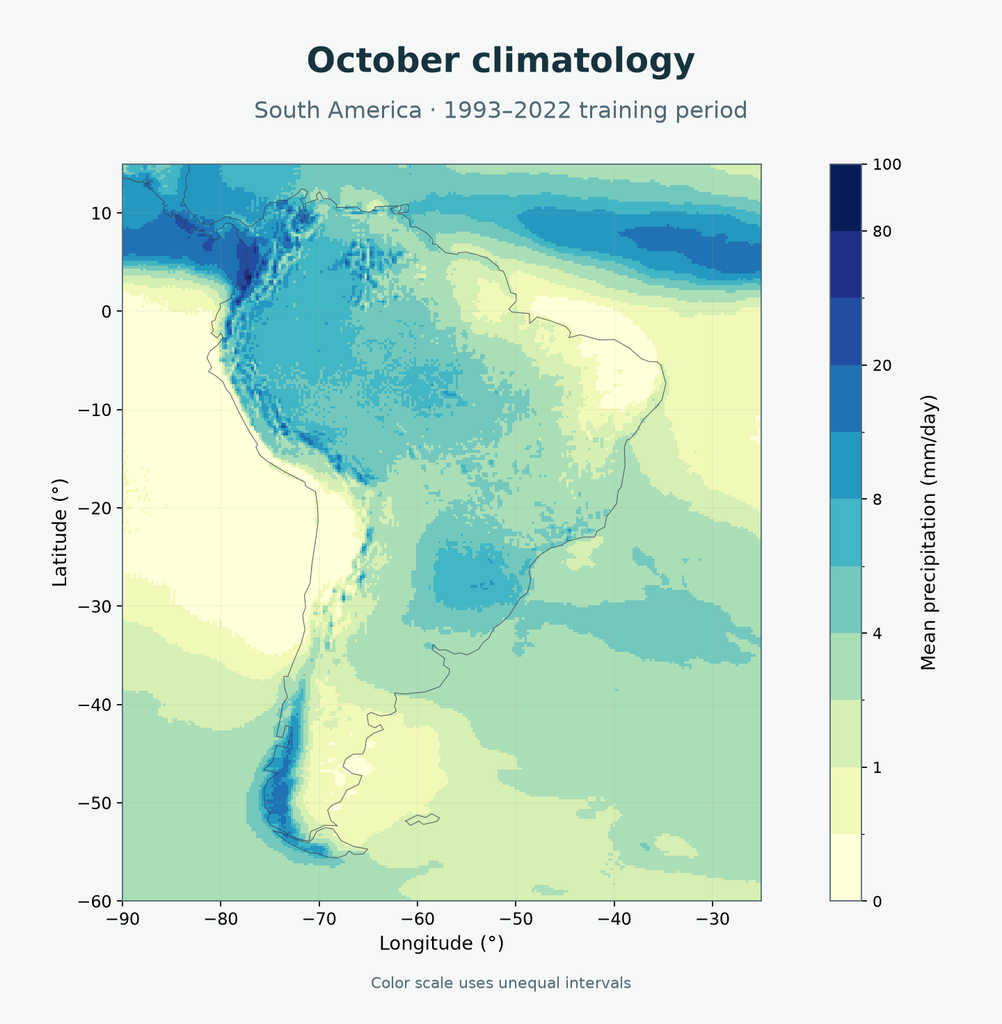

### About this map

Average rainfall for this calendar month across the training years. This historical reference uses the same color scale as the forecast.

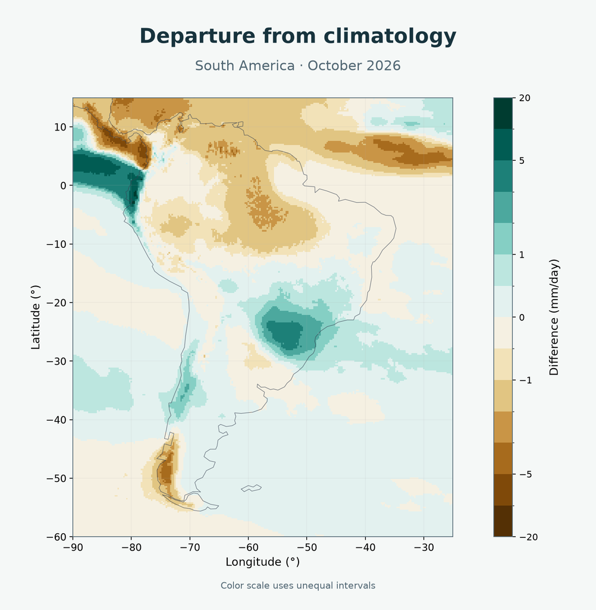

### About this map

Forecast minus the training climatology. Brown indicates drier conditions and green wetter conditions than the reference. This difference is not forecast error.

Download PNG

**Model and data sources**

The registered model uses two LightGBM models and local ridge regression, fitted on 1993–2022 with weights of 37.5%, 37.5% and 25%. Atmospheric inputs use T−4, ocean indices T−3 and seasonal initializations T−1. Required sources passed their checks before issuance.

Local receipt times and file hashes are preserved in the registry; they are not an independent external timestamp.

## Historical validation

2007–2020 · Seven two-year blocks · All metrics in mm/day

Metric

**View exact values**

**How to read these results**

The source-lag protocol differs from the competition model, so the two tabs are not a controlled paired comparison. These development years have already been consulted, so the results do not establish performance in future years. U-Net and global SST/PCA remain separate experiments.

## Try the code

[Reproduce an experiment →](https://github.com/Houxxie/worcap-2026-rainfall-forecasting/blob/main/docs/REPRODUCTION.md)[Run a monthly forecast →](https://github.com/Houxxie/worcap-2026-rainfall-forecasting/blob/main/docs/MONTHLY_FORECAST.md)

**Data and provenance**

Full runs need the documented datasets; monthly issuance also needs current sources and CDS access. The links above open the online guides. The viewer itself works offline, from saved files, without model fitting or new scoring.

Map outlines: Natural Earth, used only for display. These repository files are checked against demo/sources.json when the viewer is built:

- `competition/results/global.csv`
- `competition/results/years.csv`
- `research/lagged_sources/evidence/metricas_globais.csv`
- `research/lagged_sources/evidence/metricas_anos.csv`
- `research/prospective/evidence/issued_forecast_2026_10.json`
- `assets/competition_forecast_example.png`
- `assets/competition_forecast_example.json`
- `assets/forecast_october_2026.json`
- `assets/demo_october_forecast.png`
- `assets/demo_october_climatology.png`
- `assets/demo_october_anomaly.png`